# Hallmarks of Good Scientific Software

Science is facing a [reproducibility crisis](https://en.wikipedia.org/wiki/Replication_crisis). Poorly designed or implemented scientific software represent a major limitation in making packages reusable and analyses reproducible. In this article, I’ll break down good software engineering practices to six *hallmarks*. These hallmarks guide researchers through improving their code quality, maximizing the utility and impact of the software, and in the long run improve the perspective of replication in science.

Adhering to these guidelines is one aspect of making your research [FAIR](https://www.go-fair.org/fair-principles/) (**f**indable, **a**ccessible, **i**nteroperable and **r**eusable).

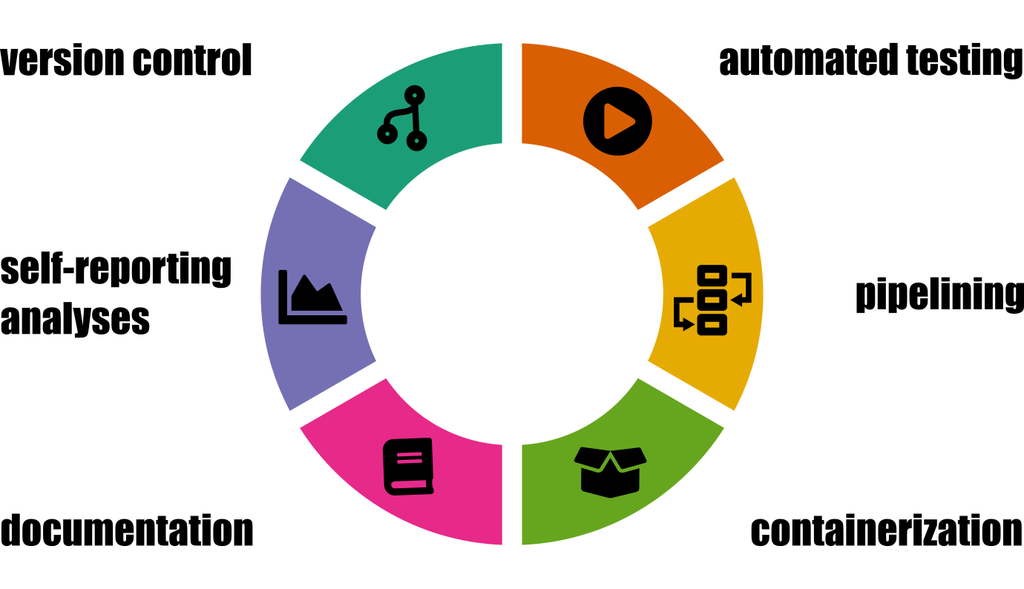

**Figure 1**: The Hallmarks of Good Scientific Software[^1]. The icons (except pipeline) are from [fontawesome](https://fontawesome.io). The figure may be reused under [CC BY 4.0](https://creativecommons.org/licenses/by/4.0/) license.

These hallmarks focus on tools and habits which will help taking your software quality to the next level. I assume that you are already familiar with the basics of *clean coding principles*, i.e. you format your code consistently, use sensible variable names, and [keep everything stupidly simple](https://en.wikipedia.org/wiki/KISS_principle). The importance of writing easy-to-read code cannot be overstated. A good starting point for learning how to write clean code is this [style guide for R](http://stat405.had.co.nz/r-style.html) and the [clean-code-python](https://github.com/zedr/clean-code-python#introduction) project.

Next, let’s distinguish between *software packages* and *data analysis reports*. Both are pieces of software which are covered by the hallmarks – however, they have slightly different priorities. Software packages are a tool, or a collection of tools which are created with the aim of being applied to different datasets. A typical example would be a sequence aligner like STAR, or a library for single-cell RNA-seq analysis like [scanpy](https://scanpy.readthedocs.io/) or [Seurat](https://satijalab.org/seurat/). The main goal of software packages is **reusability**, defined by the ability to reuse the code for multiple datasets and for diverse goals of data analysis.

In contrast, *data analysis reports* mostly build upon existing software packages and are specifically adapted to produce interpretable results for a certain dataset. The main goal of data analysis reports is **reproducibility**, defined by the ability to reproduce the results when run in another computing environment or in a later time point than when the report was written. Yet, it can often make sense to abstract a data analysis report into a reusable pipeline which can be applied to other datasets.

The first four hallmarks apply to both software packages and data analysis reports. (In fact, they apply to pretty much any kind of software):

1. Use version control ([git](https://git-scm.com/))
2. Use automated testing and continuous integration (e.g. [GitHub actions](https://github.com/features/actions))
3. Containerize all dependencies (e.g. [Docker](https://www.docker.com/), [Singularity](https://sylabs.io/docs/))
4. Write extensive, high-quality documentation (e.g. [sphinx](https://www.sphinx-doc.org/en/master/), [pkgdown](https://pkgdown.r-lib.org/))

In addition to that, two more hallmarks apply to data analysis reports:

5. Use automated reporting (e.g. [Rmarkdown](https://rmarkdown.rstudio.com/), [Jupyter notebooks](https://jupyter.org/))
6. Use a workflow manager (e.g. [nextflow](https://www.nextflow.io/), [Snakemake](https://snakemake.readthedocs.io/en/stable/))

## Use version control

[figure not shown]

The first, and arguably the most important hallmark is to use [git](https://git-scm.com)[^2]. It keeps track of all your code changes, and allows you to share your code on public repositories such as [GitHub](https://github.com/)[^3]. **Making the code publicly available and easy to be modified by others is the first step towards making your project both discoverable and reproducible.**

There are many benefits of using git and GitHub, for instance:

- You don’t need to worry about backups any more. Every version of your code you store in git can be restored at any time.
- It allows you to keep track of what you did (this is very useful when continuing on a project after several weeks of interruption).
- It allows you to synchronize changes across working environments (say laptop and server cluster) and between collaborators.
- GitHub provides an issue tracker and project management tools to keep track of bugs and suggestions.

Yet, the most important aspect of using GitHub is to get people involved with your software.  
**Communication is an essential part of the scientific process, and GitHub is the way to communicate about scientific software.** It increases your visibility in the community and makes your software being discovered more easily. You can retrieve feedback in form of bug reports, feature requests and code reviews. Others can directly contribute improvements in the form of [pull requests](https://help.github.com/en/github/collaborating-with-issues-and-pull-requests/about-pull-requests). Finally, it enables you to browse other, well-engineered pieces of software and learn from them by reading their code.

**Tool of choice:** [git](http://git-scm.com) in combination with [GitHub](https://github.com) or [GitLab](https://gitlab.com).

## Use automated testing and continuous integration

[figure not shown]

Automated testing is an industry standard in software firms for *years*, but it is terribly underused in most scientific software, particularly those developed by single contributors such as students and contractors. Automated testing does not only ensure that your software package works on other systems than yours or that you don’t break old functionality while adding new one – **it also increases the likelihood that the results your software generates are actually predictable, at least within the space of the input parameters that you can test, and correct**. The correctness of the software output is top priority for scientific software.

The concept of automated testing is simple: for every piece of code you write, you also write a *unit test* that calls the piece of code with some example data, and validates that it produces the expected result.

Initially, this might seem like a waste of time, but it isn’t: it helps to to **find bugs early**. As a result, it pays off and saves time in the long run. Finding bugs early decreases the cost for fixing them. If you detect a bug right after writing the function, you still have everything in your memory and can likely fix it within minutes. If the bug is discovered by someone else a few months later, it might take you hours or days to figure out the problem, because you have to dig into the code again. There are excellent packages for automated testing for virtually every programming language. The most common ones are [pytest](https://docs.pytest.org/en/latest/) for Python and [testthat](https://testthat.r-lib.org/) for R. Moreover, [Hypothesis](https://hypothesis.readthedocs.io/en/latest/) is a python package implementing [property-based testing](https://medium.com/criteo-labs/introduction-to-property-based-testing-f5236229d237), which holds the promise to facilitate writing tests while covering a larger set of test cases.

Writing tests by itself is not helpful if they are not executed on a regular basis. This is where *continuous integration* comes into place. Continuous integration runs your tests every time you upload your code on e.g. GitHub and notifies you if the tests fail. By combining continuous integration with a [branch-and-pull-request workflow](https://guides.github.com/introduction/flow/), you ensure that the code on your master branch is always fully tested. You are notified when tests fail, therefore increasing the chance to fix bugs early and quickly.

**Tools of choice**: [pytest](https://docs.pytest.org/en/latest/) and [Hypothesis](https://hypothesis.readthedocs.io/en/latest/) for Python packages, [testthat](https://testthat.r-lib.org/) for R packages. [GitHub Actions](https://docs.github.com/en/actions) for continuous integration.

## Containerize dependencies

[figure not shown]

> If I have seen further it is by standing on the shoulders of Giants.

*(Isaac Newton, 1675)*

This is definitely true for scientific software. Most software packages and data analyses would not be possible without giants like [dplyr](https://dplyr.tidyverse.org/), [ggplot2](https://ggplot2.tidyverse.org/), [numpy](https://numpy.org/), [scipy](https://www.scipy.org/) and many more domain-specific packages. Unfortunately, complex dependencies make it hard to install and run your software. They also hamper reproducibility of your analysis as different versions might be incompatible or produce slightly different results. This phenomenon is commonly referred to as the *[dependency hell](https://en.wikipedia.org/wiki/Dependency_hell).*

Therefore, it is vital to accurately declare all dependencies required for your software to run, **down to the exact version number**. The most reliable way of doing so is to build a *container* with all software required to run your software. That way, your package or analysis can be ran in exactly the same software environment you have been using. Containers are one of the few ways to ensure that your analysis can be ran in a few years from now[^4].

For software packages (as opposed to data analysis reports) it is also appropriate to declare the dependencies in the format of the corresponding package manager. This could be a [DESCRIPTION file](http://r-pkgs.had.co.nz/description.html) for R, a [setup.py file](https://python-packaging.readthedocs.io/en/latest/dependencies.html) for python, or a [conda recipe](https://docs.conda.io/projects/conda-build/en/latest/resources/define-metadata.html#source-section). Arguably, the best option is to offer both: properly declared dependencies and a container.

**Tools of choice**: [Singularity](https://sylabs.io/docs/) and [Docker](https://www.docker.com/) for data analyses. [Bioconda](https://bioconda.github.io/) or [conda-forge](https://conda-forge.org/) for software packages.

## Write extensive, high-quality documentation

[figure not shown]

Documentation is an essential part of each software. **Without proper documentation, the most elegant piece of software can be useless.** As a rule of thumb, the documentation should have at least as many lines as the source code. Documentation helps users getting started with your software quickly and vastly increases the potential userbase.

For software packages, good documentation consists, one the one hand, of a documentation of the public interface (API). The API consists of all functions, classes etc. which are exposed to the end user. The API documentation describes the input parameters and results for each function. On the other hand, the documentation should comprise instructions on how to install the package and a step-by-step tutorial teaching the user to apply the software to real-world datasets.

For data analysis reports, it is best to mix the documentation with the code (see self-reporting analyses). Moreover, it is vital to provide step-by-step instructions on how to rerun the analysis.

**Tools of choice**: [sphinx](https://www.sphinx-doc.org/en/master/) (Python/general purpose) and [pkgdown](https://pkgdown.r-lib.org/) for R.

## Write self-reporting data-analyses

[figure not shown]

It is common practice to run a few commands in an R shell to produce a plot and then copy and paste it to a PowerPoint presentation. **This is not only terrible from a reproducibility perspective, it is also inefficient and error-prone.** It is inefficient, because you have to re-do the plot manually if you change your preprocessing or get new data. It is error-prone, because you’ll forget to update all plots and old (wrong) versions keep floating around.

By using self-reporting data analyses this process gets streamlined and automated. An excellent way to write self-reporting data analyses are *Notebooks*. Notebooks are an implementation of [literate programming](https://en.wikipedia.org/wiki/Literate_programming), a way of mixing computer code with prose language. In this way, you can explain your data and your results at the same place where you perform the analysis. Notebooks can be rendered into beautiful web-pages, presentations, or PDF documents which you can directly share with your collaborators. Finally, you can publish them alongside your paper ensuring other researchers can understand your analysis.

However, notebooks are a *terrible* tool to develop software packages. Only use them to describe your analysis using high-level functions and factor out all longer, repetitive code-snippets into an external software package. The package can be properly tested using automated testing as described above, and re-used for other projects, saving you time in the long run. For more background, read [this post by Yihui Xie](https://yihui.org/en/2018/09/notebook-war/).

**Tools of choice:** [Rmarkdown](https://rmarkdown.rstudio.com/) and [bookdown](https://bookdown.org/home/) when using R, [Jupyter notebooks](https://jupyter.org/), and [jupyter book](https://jupyterbook.org/intro.html) for Python and other languages.

## Use a workflow manager

[figure not shown]

While notebooks are great for documenting and streamlining downstream analyses, they are unsuitable for computationally expensive tasks like preprocessing raw sequencing files. Similar to the downstream analyses, **the naive approach is to write a few bash scripts and run them on a workstation or submit them to a high performance cluster (HPC). Again, this is irreproducible, inefficient and error-prone.** It is irreproducible, because it is hard to appreciate in which order the scripts need to be ran. Moreover, the scripts are likely to be specific for the scheduler used on your HPC. It is inefficient, because you manually need to ensure that all jobs completed successfully before running the next step. It is error-prone, because it is easy to forget to re-execute certain steps after changing parameters or fixing bugs.

By using a *workflow manager*, you solve all these problems. In a pipeline-script, you implicitly document which of your analysis-steps depends on which input-files and intermediate results and thereby, in which order they need to be executed. The workflow manager takes care of executing the individual steps **in parallel** wherever possible and makes sure to only re-compute parts that were modified. Moreover, it abstracts the pipeline logic from the system used for execution, enabling your pipeline to **run everywhere**, be it on a personal computer, institutional HPC or cloud instances.

Workflow managers play well with the other concepts discussed in this article. They can directly execute pipelines from GitHub, execute tasks in containers and can be used to [tie together multiple notebooks](https://grst.github.io/bioinformatics/2019/12/23/reportsrender.html). In brief, by providing a pipeline, other researchers can reliably reproduce your entire analysis with a single-command.

Finally, when developing re-usable software packages, it can often make sense to build upon a workflow manager. Many problems, like parallelization, submitting jobs to HPC or cloud instances, caching, etc. has already been excellently solved by these tools and there is no need to re-invent the wheel.

**Tools of choice:** [nextflow](https://www.nextflow.io/) or [Snakemake](https://snakemake.readthedocs.io/en/stable/)[^5]

## Further reading

In this article, I gave a high-level overview of the hallmarks. For a hands-on tutorial I recommend [this training material](https://nbis-reproducible-research.readthedocs.io/en/latest/repres_project/) by the [NBIS](https://www.nbis.se/). Quite recently a [review preprint](https://www.biorxiv.org/content/10.1101/2020.06.30.178673v1.abstract?%3Fcollection=) about how and why you should use pipelining engines has been published on biorXiv.

## Acknowledgements

I would like to thank [Jitao David Zhang](https://jdzhang.me) for his feedback on this article.

## Footnotes

[^1]: Of course, the title and the figure are inspired by [the hallmarks of cancer](https://doi.org/10.1016/j.cell.2011.02.013).
[^2]: There are other version control systems than git, but they play a diminishing role nowadays.
[^3]: [GitLab](https://about.gitlab.com/) is an alternative to GitHub which is becoming more and more popular. In contrast to GitHub it is open source and can be installed on your own servers. Nevertheless, GitHub is where all the developers are and that’s where you want your project to be for being discovered.
[^4]: Another way is to buy a new server every time you publish a paper, keep that running and bill your funding agency for it. I long believed that by [exporting a conda environment](https://docs.conda.io/projects/conda/en/latest/user-guide/tasks/manage-environments.html#sharing-an-environment) the same can be achieved, but was proven wrong. See the [discussion on GitHub](https://github.com/conda/conda/issues/9257).
[^5]: Both nextflow and Snakemake are excellent. I personally prefer nextflow because I find it easier to get started with. See also my [comparison on GitHub](https://github.com/grst/snakemake%5B%5Ex%5D:_nextflow_wdl).